# 1.2-bmk-data-transforming

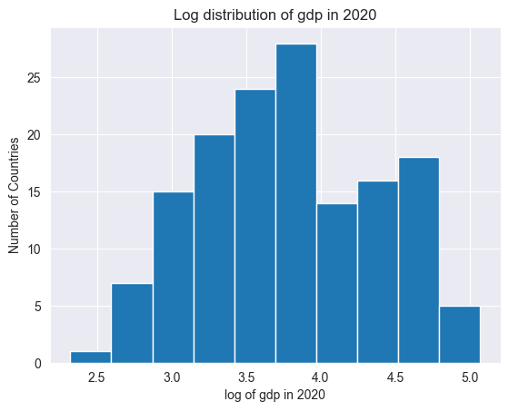

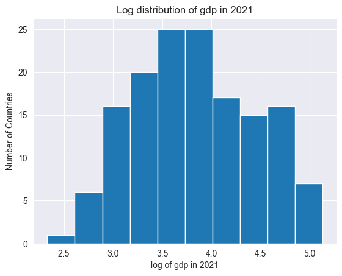

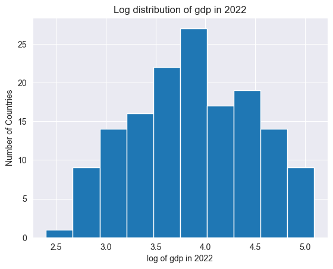

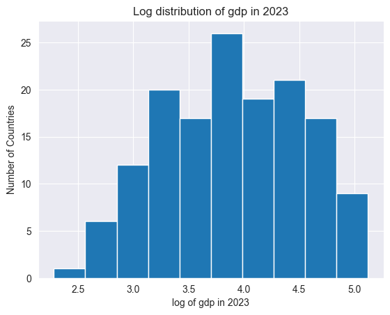

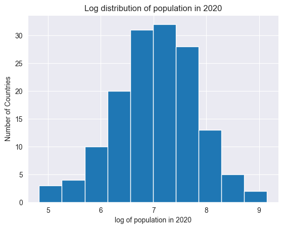

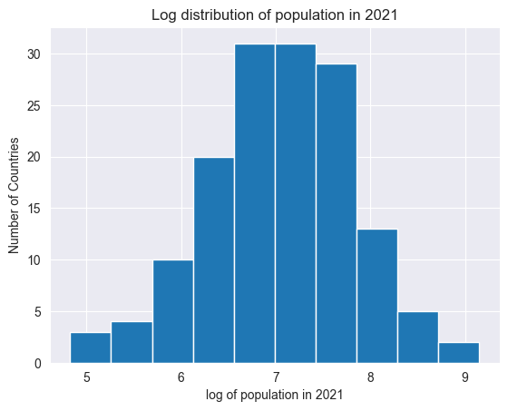

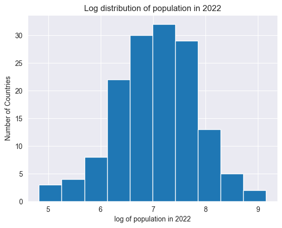

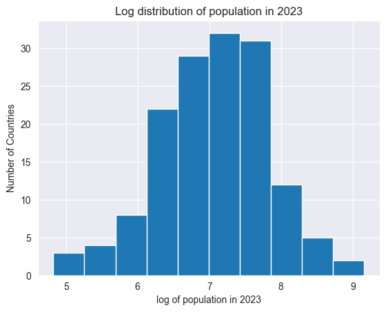

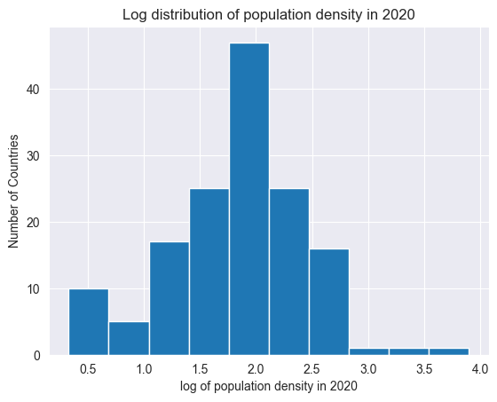

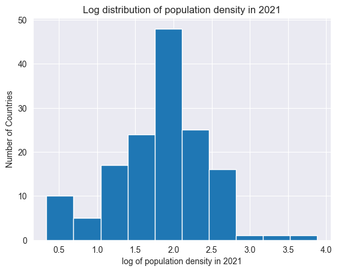

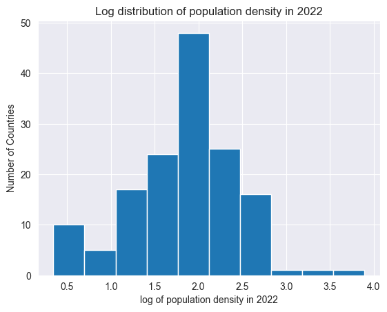

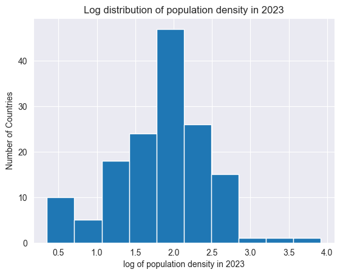

[4 more figures not shown]

```python
for column in ['log_gdp data in 2020',
       'log_gdp data in 2021', 'log_gdp data in 2022', 'log_gdp data in 2023',
       'log_population data in 2020', 'log_population data in 2021',
       'log_population data in 2022', 'log_population data in 2023',
       'log_population density in 2020', 'log_population density in 2021',
       'log_population density in 2022', 'log_population density in 2023',
       'democracy index data in 2020', 'democracy index data in 2021',
       'democracy index data in 2022', 'democracy index data in 2023']:
    plt.hist(data[column])
    display_name = column.replace('data ', '')
    display_name = display_name.replace('log_', 'log of ')
    plt.xlabel(display_name)
    display_name = display_name.replace('log of ', '')
    plt.ylabel('Number of Countries')
    if column[0:9] == 'democracy':
        plt.title('Distribution of ' + display_name)
    else:
        plt.title('Log distribution of ' + display_name)
    plt.show()
```

Those are far nicer distributions! Note that we took a log base 10, so a value of n means 1 followed by n zeros. Now, let's do a little bit of bivariate analysis to see what correlations can be inferred here.

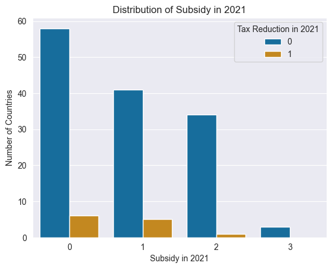

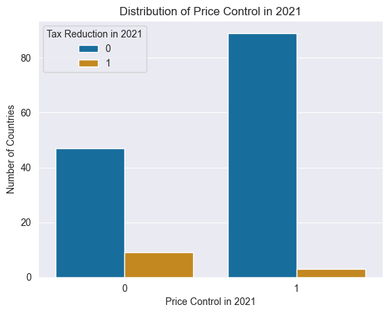

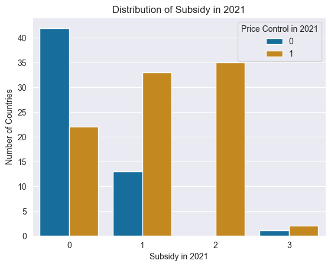

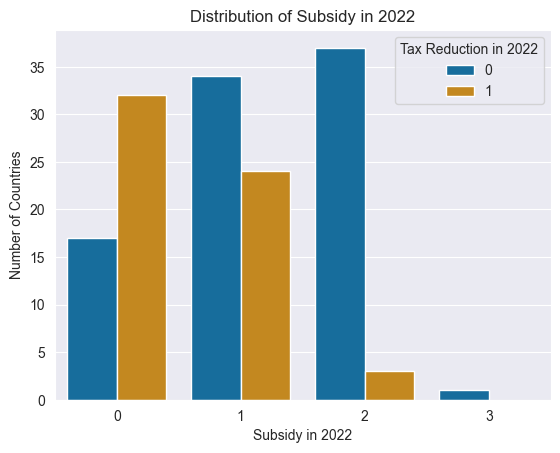

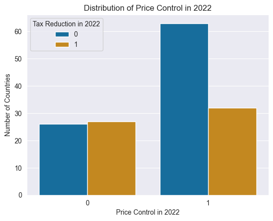

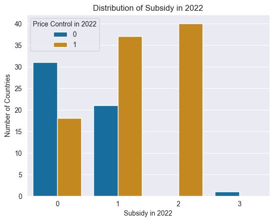

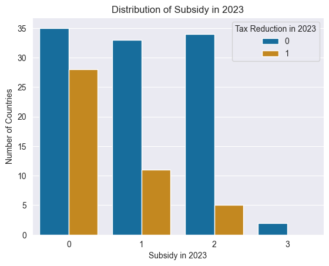

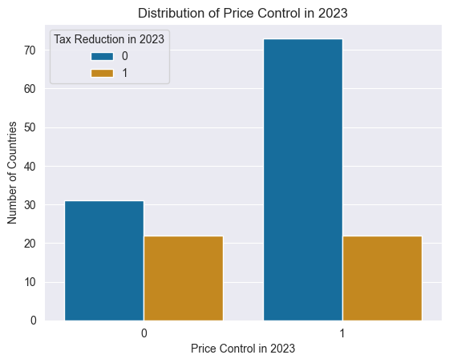

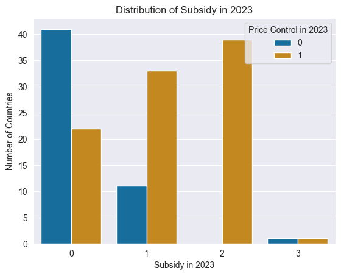

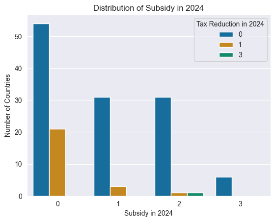

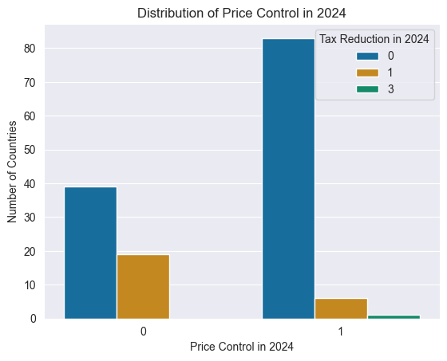

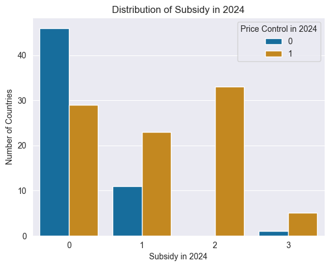

```python
for year in range(2021,2025):
    column = 'Subsidy in ' + str(year)
    sns.countplot(data, x = column, hue='Tax Reduction in ' + str(year), palette='colorblind')
    plt.xlabel(column)
    plt.ylabel('Number of Countries')
    plt.title('Distribution of ' + column)
    plt.show()
    column = 'Price Control in ' + str(year)
    sns.countplot(data, x = column, hue='Tax Reduction in ' + str(year), palette='colorblind')
    plt.xlabel(column)
    plt.ylabel('Number of Countries')
    plt.title('Distribution of ' + column)
    plt.show()
    column = 'Subsidy in ' + str(year)
    sns.countplot(data, x = column, hue='Price Control in ' + str(year), palette='colorblind')
    plt.xlabel(column)
    plt.ylabel('Number of Countries')
    plt.title('Distribution of ' + column)
    plt.show()
```

From this, we can see a couple things. Correlations are mostly consistent across years. Countries with subsidies are more likely to directly regulate prices. This makes sense, since both tools are generally used to achieve similar goals. In addition, tax reductions and subsidies are negatively correlated. This may mean that tax reductions can be used as a substitute for direct subsidies.

For the next bivariate analysis, we will take only the latest year, as this will reveal all major trends without creating too many graphs.

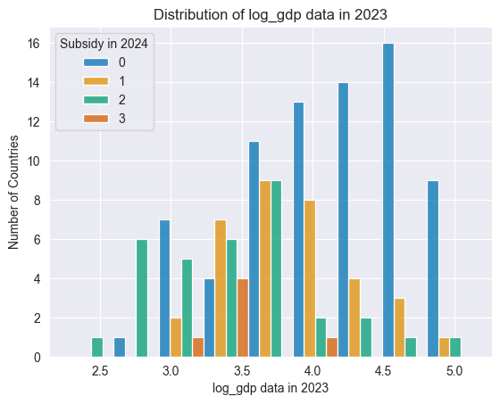

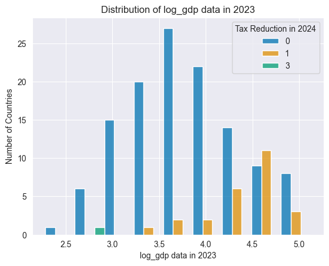

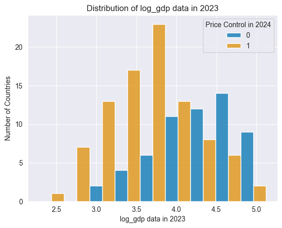

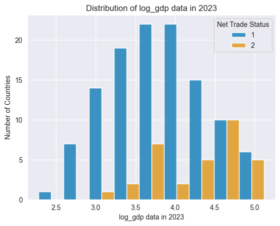

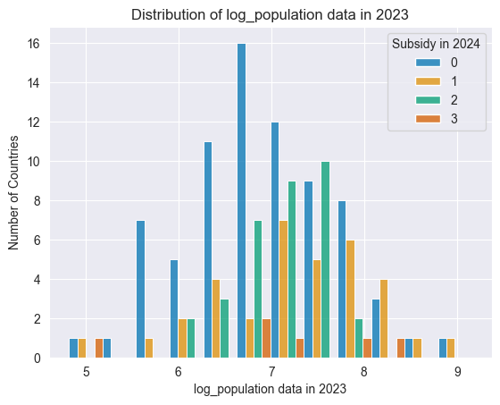

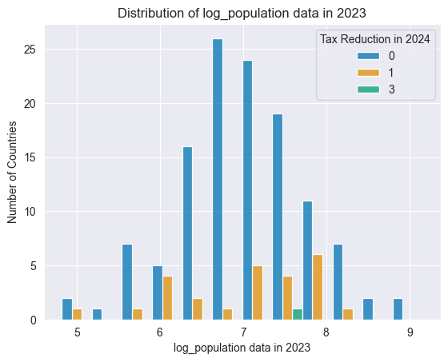

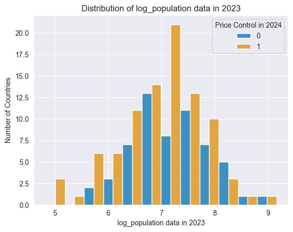

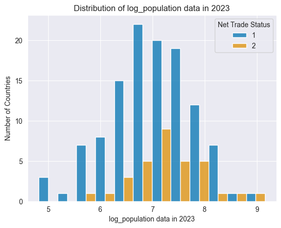

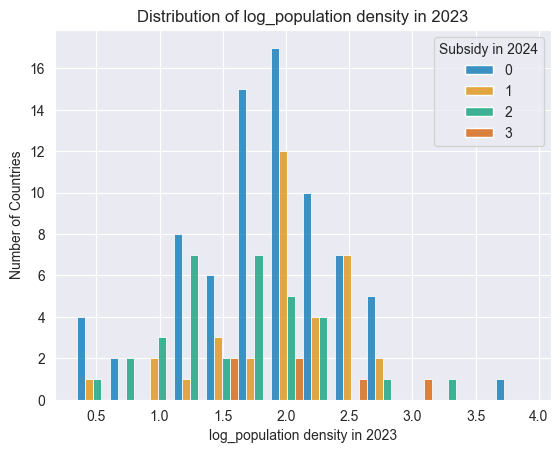

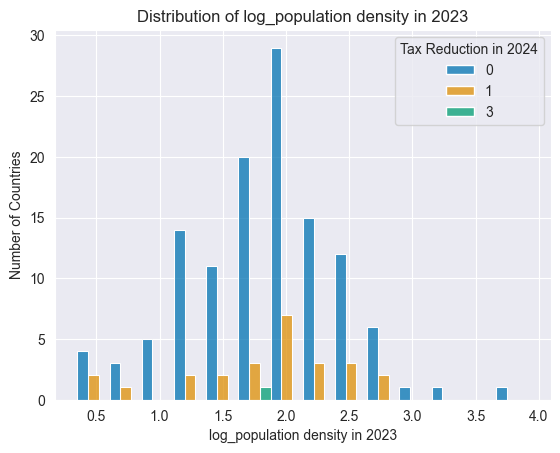

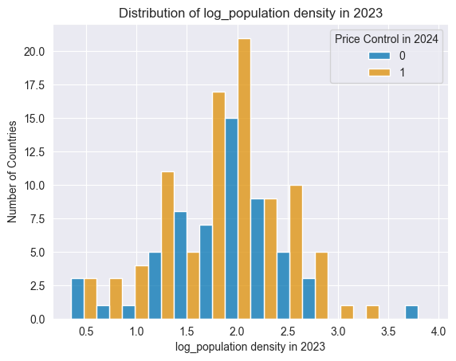

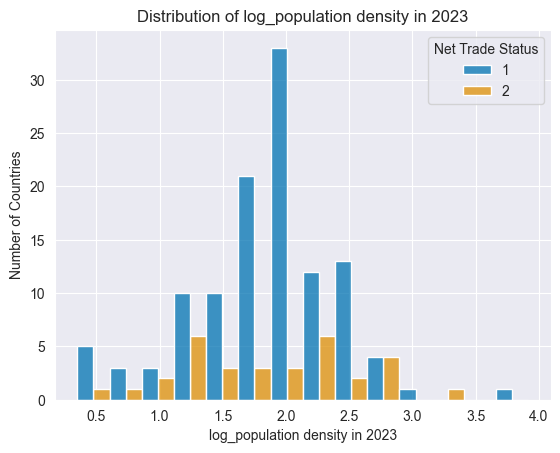

[4 more figures not shown]

```python
for basic_data_column in ['log_gdp data in ', 'log_population data in ', 'log_population density in ', 'democracy index data in ']:
    for subsidy_field_name in ['Subsidy in ', 'Tax Reduction in ', 'Price Control in ']:
        column = basic_data_column + '2023'
        sns.histplot(data, x = column, hue = subsidy_field_name + '2024', multiple="dodge", palette='colorblind')
        plt.xlabel(column)
        plt.ylabel('Number of Countries')
        plt.title('Distribution of ' + column)
        plt.show()
    column = basic_data_column + '2023'
    sns.histplot(data, x = column, hue = 'Net Trade Status', multiple="dodge", palette='colorblind')
    plt.xlabel(column)
    plt.ylabel('Number of Countries')
    plt.title('Distribution of ' + column)
    plt.show()
```

]We can notice a few correlations here as well. First, there is a large negative correlation between subsidies and a country's GDP. In other words, poor countries implement oil subsidies and price controls far more often than wealthy ones. Conversely, tax reductions are far more common in wealthy countries, suggesting that wealthy countries often use tax reductions similarly to how poor countries use subsidies. Wealthy countries are also far more likely to be net exporters of refined oil products. However, from this data alone, it is impossible to tell if exporting refined oil causes a country to get wealthy, having wealth causes a country to have refined oil to export, or if some other confounding variable is causing the correlation. Finally, we can see that the less democratic a country is, the higher the likelihood of that country regularly freezing prices.

```python
# Manipulating categorical variables to make them quantitative
for year in range(2021,2025,1):
    tax_field_name = 'Tax Reduction in ' + str(year)
    subsidy_field_name = 'Subsidy in ' + str(year)
    data = pd.get_dummies(data, columns=[subsidy_field_name], dtype=int)
    print(data.head())
    # Naming columns based on the meaning of each value, and dropping the column corresponding to unclear. This value will be indicated by 0s in all other columns.
    data.drop(['Subsidy in ' + str(year) + '_3'], axis=1, inplace=True)
    data.rename(columns={'Subsidy in ' + str(year) + '_0':'No subsidy in ' + str(year), 'Subsidy in ' + str(year) + '_1':'Some subsidy in ' + str(year), 'Subsidy in ' + str(year) + '_2': 'Price freezes in ' + str(year)}, inplace=True)

    # Replacing the single unclear value so data fits into model nicely
    data[tax_field_name].replace(3, 0, inplace=True)
    print(data.head())
    print(data.columns)
```

```
  Country Code  Net Trade Status  Price Control in 2021  \
0          ALB                 1                      0
1          DZA                 2                      1
2          AGO                 1                      1
3          ARG                 1                      1
4          ARM                 1                      0

   Tax Reduction in 2021  Price Control in 2022  Subsidy in 2022  \
0                      0                      1                1
1                      0                      1                2
2                      0                      1                2
3                      0                      1                0
4                      0                      0                0

   Tax Reduction in 2022  Price Control in 2023  Subsidy in 2023  \
0                      0                      1                1
1                      0                      1                2
2                      0                      1                2
3                      1                      1                0
4                      0                      0                0

   Tax Reduction in 2023  ...  log_population density in 2022  \
0                      0  ...                        2.005933
1                      0  ...                        1.280901
2                      0  ...                        1.456115
3                      0  ...                        1.219906
4                      0  ...                        2.022416

   log_population data in 2022  log_gdp data in 2022  \
0                     6.443684              3.835464
1                     7.657796              3.695618
2                     7.551877              3.466822
3                     7.657131              4.144128
4                     6.472639              3.817696

   log_population density in 2023  log_population data in 2023  \
0                        2.000946                     6.438696
1                        1.287411                     7.664305
2                        1.469494                     7.565256
3                        1.221152                     7.658378
```

[output cut: 432 more lines]

```
       'Tax Reduction in 2023', 'Price Control in 2024',
       'Tax Reduction in 2024', 'democracy index data in 2020',
       'democracy index data in 2021', 'democracy index data in 2022',
       'democracy index data in 2023', 'log_population density in 2020',
       'log_population data in 2020', 'log_gdp data in 2020',
       'log_population density in 2021', 'log_population data in 2021',
       'log_gdp data in 2021', 'log_population density in 2022',
       'log_population data in 2022', 'log_gdp data in 2022',
       'log_population density in 2023', 'log_population data in 2023',
       'log_gdp data in 2023', 'No subsidy in 2021', 'Some subsidy in 2021',
       'Price freezes in 2021', 'No subsidy in 2022', 'Some subsidy in 2022',
       'Price freezes in 2022', 'No subsidy in 2023', 'Some subsidy in 2023',
       'Price freezes in 2023', 'No subsidy in 2024', 'Some subsidy in 2024',
       'Price freezes in 2024'],
      dtype='object')
```

Now all of our data is nice and quantitative, and we are ready to start building models with it. After building some models, we may do additional transformations to try to improve performance, but this dataset is what we are starting with for model building.

```python
data.to_csv('../data/processed/transformed_data.csv')
```